# Chapter 4 tables and graphs

2021-02-01

```r
library(xtable)
library(countrycode)
library(magrittr)
library(jtools)
library(lmtest)
library(gridExtra)
library(pastecs)
library(plm)
options(scipen = 999)
```

## Prepare the data

```r
rm(list = ls())
source("r-codes/dataprep.R")
```

```
## restatapi: - config file with the API version 1 loaded from GitHub (the 'current' API version number is 1).
##            - 4 from the 32 cores are used for parallel computing.
##            - 'libcurl' will be used for file download.
##            - the Table of contents (TOC) was not pre-loaded into the deafult cache ('.restatapi_env').
```

```
## No data retrieved for the given filter(s), because the results are too big to download immediately through the REST API. The whole dataset is downloaded through the raw download and the filters are applied locally.
```

```
## Info: (Data scanned: 1.01 GB)
```

## Table 3

Number of observations by quarter in country

```r
 dcast(oja,countries~time,fun.aggregate=sum,value.var='vals') %>%
  xtable(digits = 0,
         caption = "Number of advertisements active at the end of each quarter") %>%
  print.xtable(include.colnames = T, include.rownames = F,
               format.args = list(big.mark = ",", decimal.mark = ""),
               caption.placement = "top")
```

```
## % latex table generated in R 4.0.3 by xtable 1.8-4 package
## % Mon Feb  1 22:09:43 2021
## \begin{table}[ht]
## \centering
## \caption{Number of advertisements active at the end of each quarter}
## \begin{tabular}{lrrrrrr}
##   \hline
## countries & 2018-Q3 & 2018-Q4 & 2019-Q1 & 2019-Q2 & 2019-Q3 & 2019-Q4 \\
##   \hline
## Austria & 281,546 & 298,612 & 364,221 & 214,306 & 223,323 & 138,868 \\
##   Belgium & 305,807 & 367,834 & 599,394 & 515,096 & 452,800 & 333,538 \\
##   Bulgaria & 11,919 & 34,977 & 83,908 & 60,684 & 49,132 & 33,602 \\
##   Croatia & 2,086 & 7,158 & 22,813 & 23,398 & 18,406 & 19,502 \\
##   Cyprus & 1,434 & 2,946 & 8,175 & 6,404 & 7,263 & 4,298 \\
##   Czechia & 93,145 & 138,361 & 264,765 & 239,250 & 225,002 & 138,011 \\
##   Denmark & 10,337 & 26,902 & 87,021 & 58,743 & 61,989 & 59,240 \\
##   Estonia & 1,049 & 4,972 & 11,314 & 10,430 & 8,879 & 7,707 \\
##   Finland & 13,975 & 27,810 & 81,143 & 55,687 & 60,678 & 42,939 \\
##   France & 1,999,566 & 2,660,478 & 3,293,666 & 2,075,295 & 2,821,807 & 3,123,865 \\
##   Germany & 2,356,289 & 3,286,338 & 4,607,939 & 2,618,403 & 2,771,006 & 1,767,932 \\
##   Greece & 365 & 3,870 & 14,326 & 13,831 & 10,380 & 8,957 \\
##   Hungary & 18,474 & 29,377 & 83,125 & 60,492 & 73,386 & 44,816 \\
##   Ireland & 105,512 & 135,307 & 180,270 & 161,850 & 149,908 & 111,068 \\
##   Italy & 423,393 & 576,520 & 817,059 & 501,388 & 730,925 & 797,023 \\
##   Latvia & 708 & 6,446 & 25,751 & 20,126 & 16,144 & 14,929 \\
##   Lithuania & 1,476 & 9,832 & 24,365 & 24,817 & 24,912 & 20,973 \\
##   Luxembourg & 10,992 & 17,810 & 23,070 & 23,355 & 21,214 & 18,625 \\
##   Malta & 2,648 & 6,222 & 2,981 & 3,218 & 2,689 & 1,875 \\
##   Netherlands & 574,150 & 692,293 & 864,496 & 462,977 & 599,563 & 752,627 \\
##   Poland & 309,962 & 320,509 & 400,852 & 265,979 & 402,984 & 376,891 \\
##   Portugal & 40,806 & 71,498 & 79,903 & 68,078 & 74,404 & 45,940 \\
##   Romania & 17,074 & 43,203 & 134,329 & 80,192 & 91,859 & 67,940 \\
##   Slovakia & 22,710 & 22,605 & 63,673 & 49,356 & 53,989 & 44,726 \\
##   Slovenia & 2,833 & 1,499 & 12,555 & 15,262 & 14,709 & 11,000 \\
##   Spain & 226,842 & 314,062 & 532,433 & 511,229 & 521,692 & 411,553 \\
##   Sweden & 104,367 & 196,539 & 355,811 & 240,500 & 158,650 & 126,353 \\
##    \hline
## \end{tabular}
## \end{table}
```

## Table 4

Number of unique data sources overtime

```r
oja_db[idcountry != "UK", lapply(.SD, sum),  keyby = .(idcountry, source), .SDcols = t2018Q3:t2019Q4] %>%
  gather(quarter, vals, t2018Q3:t2019Q4) %>%
  filter(vals >0) %>%
  count(idcountry, quarter) %>%
  spread(quarter, n) %>%
  mutate(idcountry = countrycode(idcountry, "eurostat","country.name")) %>%
  rename(Country="idcountry") %>%
  xtable(digits = 0,
         caption = "Number of unique sources of advertisements in Cedefop’s OJA dataset, by quarter") %>%
  print.xtable(include.colnames = T, include.rownames = F,
               format.args = list(big.mark = ",", decimal.mark = ""),
               caption.placement = "top")
```

```
## % latex table generated in R 4.0.3 by xtable 1.8-4 package
## % Mon Feb  1 22:10:00 2021
## \begin{table}[ht]
## \centering
## \caption{Number of unique sources of advertisements in Cedefop’s OJA dataset, by quarter}
## \begin{tabular}{lrrrrrr}
##   \hline
## Country & t2018Q3 & t2018Q4 & t2019Q1 & t2019Q2 & t2019Q3 & t2019Q4 \\
##   \hline
## Austria & 91 & 112 & 135 & 105 & 107 & 90 \\
##   Belgium & 132 & 159 & 170 & 160 & 142 & 138 \\
##   Bulgaria & 111 & 137 & 167 & 139 & 126 & 123 \\
##   Cyprus & 40 & 76 & 94 & 73 & 62 & 55 \\
##   Czechia & 63 & 83 & 106 & 87 & 71 & 52 \\
##   Germany & 147 & 171 & 186 & 175 & 156 & 141 \\
##   Denmark & 31 & 54 & 59 & 51 & 36 & 48 \\
##   Estonia & 32 & 61 & 91 & 65 & 50 & 44 \\
##   Greece & 17 & 35 & 49 & 45 & 39 & 57 \\
##   Spain & 115 & 149 & 170 & 159 & 138 & 125 \\
##   Finland & 45 & 68 & 86 & 66 & 65 & 61 \\
##   France & 152 & 186 & 205 & 192 & 192 & 175 \\
##   Croatia & 74 & 94 & 104 & 98 & 83 & 78 \\
##   Hungary & 99 & 120 & 132 & 120 & 101 & 91 \\
##   Ireland & 119 & 132 & 158 & 129 & 126 & 110 \\
##   Italy & 133 & 174 & 183 & 177 & 165 & 157 \\
##   Lithuania & 34 & 63 & 83 & 67 & 53 & 49 \\
##   Luxembourg & 53 & 68 & 63 & 55 & 62 & 55 \\
##   Latvia & 16 & 32 & 57 & 34 & 30 & 24 \\
##   Malta & 50 & 59 & 61 & 50 & 53 & 45 \\
##   Netherlands & 134 & 155 & 187 & 164 & 155 & 142 \\
##   Poland & 60 & 87 & 103 & 83 & 71 & 66 \\
##   Portugal & 112 & 135 & 144 & 132 & 123 & 113 \\
##   Romania & 117 & 139 & 176 & 151 & 141 & 129 \\
##   Sweden & 87 & 98 & 124 & 101 & 91 & 76 \\
##   Slovenia & 42 & 51 & 63 & 49 & 45 & 45 \\
##   Slovakia & 76 & 99 & 117 & 91 & 83 & 70 \\
##    \hline
## \end{tabular}
## \end{table}
```

How stable are data sources?

```r
oja_db[idcountry != "UK", lapply(.SD, sum),  keyby = .(idcountry, source), .SDcols = t2018Q3:t2019Q4] %>%
  gather(quarter, vals, t2018Q3:t2019Q4) %>%
  filter(vals >0) %>%
  add_count(idcountry, source, name  = "vals") %>%
  count(idcountry, source, vals) %>%
  group_by(idcountry) %>%
  summarise(Whole_period = sum(vals == 6), Total = n(), Share = Whole_period/Total*100) %>%
  mutate(idcountry = countrycode(idcountry, "eurostat","country.name")) %>%
  rename(Country="idcountry") %>%
  xtable(digits = 2,
         caption = "Number of unique sources of advertisements in Cedefop’s OJA dataset, by quarter") %>%
  print.xtable(include.colnames = T, include.rownames = F,
               caption.placement = "top")
```

```
## % latex table generated in R 4.0.3 by xtable 1.8-4 package
## % Mon Feb  1 22:10:05 2021
## \begin{table}[ht]
## \centering
## \caption{Number of unique sources of advertisements in Cedefop’s OJA dataset, by quarter}
## \begin{tabular}{lrrr}
##   \hline
## Country & Whole\_period & Total & Share \\
##   \hline
## Austria &  48 & 177 & 27.12 \\
##   Belgium &  84 & 210 & 40.00 \\
##   Bulgaria &  66 & 201 & 32.84 \\
##   Cyprus &  17 & 125 & 13.60 \\
##   Czechia &  30 & 144 & 20.83 \\
##   Germany & 102 & 218 & 46.79 \\
##   Denmark &  16 &  95 & 16.84 \\
##   Estonia &  15 & 116 & 12.93 \\
##   Greece &  14 &  84 & 16.67 \\
##   Spain &  72 & 204 & 35.29 \\
##   Finland &  20 & 124 & 16.13 \\
##   France & 118 & 242 & 48.76 \\
##   Croatia &  34 & 155 & 21.94 \\
##   Hungary &  49 & 174 & 28.16 \\
##   Ireland &  71 & 189 & 37.57 \\
##   Italy &  96 & 226 & 42.48 \\
##   Lithuania &  21 & 117 & 17.95 \\
##   Luxembourg &  29 & 103 & 28.16 \\
##   Latvia &   8 &  74 & 10.81 \\
##   Malta &  20 & 102 & 19.61 \\
##   Netherlands &  84 & 222 & 37.84 \\
##   Poland &  26 & 144 & 18.06 \\
##   Portugal &  63 & 183 & 34.43 \\
##   Romania &  80 & 206 & 38.83 \\
##   Sweden &  42 & 163 & 25.77 \\
##   Slovenia &  20 &  95 & 21.05 \\
##   Slovakia &  40 & 154 & 25.97 \\
##    \hline
## \end{tabular}
## \end{table}
```

# Table 5

```r
rbind(
  oja_db[(t2018Q3), .N, .(idcountry, general_id, source)][, .N, .(idcountry, general_id)][
  , .N, .(idcountry, times = N)][, quarter := "t2018Q3"],
  oja_db[(t2018Q4), .N, .(idcountry, general_id, source)][, .N, .(idcountry, general_id)][
  , .N, .(idcountry, times = N)][, quarter := "t2018Q4"],
  oja_db[(t2019Q1), .N, .(idcountry, general_id, source)][, .N, .(idcountry, general_id)][
  , .N, .(idcountry, times = N)][, quarter := "t2019Q1"],
  oja_db[(t2019Q2), .N, .(idcountry, general_id, source)][, .N, .(idcountry, general_id)][
  , .N, .(idcountry, times = N)][, quarter := "t2019Q2"],
  oja_db[(t2019Q3), .N, .(idcountry, general_id, source)][, .N, .(idcountry, general_id)][
  , .N, .(idcountry, times = N)][, quarter := "t2019Q3"],
  oja_db[(t2019Q4), .N, .(idcountry, general_id, source)][, .N, .(idcountry, general_id)][
  , .N, .(idcountry, times = N)][, quarter := "t2019Q4"]
) -> oja_db_unique_sources


oja_db_unique_sources[order(idcountry,quarter, times)] %>%
  count(idcountry, quarter, times = ifelse(times > 3, 4, times), wt = N)  %>%
  mutate(idcountry = countrycode(idcountry, "eurostat","country.name")) %>%
  group_by(idcountry,  times) %>%
  summarise(n = mean(n)) %>%
  spread(times, n, fill = 0) %>%
  rename(Country="idcountry",'4 and more'="4") %>%
  xtable(digits = 0,
         caption = "Average number of advertisements occurring on one, two, three and four and more sources advertisements between 2018Q3 and 2019Q4") %>%
  print.xtable(include.colnames = T, include.rownames = F,
               format.args = list(big.mark = ",", decimal.mark = ""),
               caption.placement = "top")
```

```
## % latex table generated in R 4.0.3 by xtable 1.8-4 package
## % Mon Feb  1 22:11:14 2021
## \begin{table}[ht]
## \centering
## \caption{Average number of advertisements occurring on one, two, three and four and more sources advertisements between 2018Q3 and 2019Q4}
## \begin{tabular}{lrrrr}
##   \hline
## Country & 1 & 2 & 3 & 4 and more \\
##   \hline
## Austria & 229,314 & 9,831 & 1,213 & 200 \\
##   Belgium & 401,652 & 12,952 & 449 & 41 \\
##   Bulgaria & 43,830 & 852 & 51 & 5 \\
##   Croatia & 15,339 & 100 & 6 & 2 \\
##   Cyprus & 5,009 & 36 & 6 & 1 \\
##   Czechia & 154,305 & 13,129 & 718 & 80 \\
##   Denmark & 50,236 & 228 & 6 & 1 \\
##   Estonia & 7,324 & 32 & 1 & 1 \\
##   Finland & 45,157 & 867 & 45 & 8 \\
##   France & 2,371,491 & 114,525 & 15,640 & 3,448 \\
##   Germany & 2,611,564 & 116,131 & 15,134 & 2,795 \\
##   Greece & 7,827 & 367 & 22 & 3 \\
##   Hungary & 45,909 & 2,617 & 108 & 33 \\
##   Ireland & 122,732 & 8,505 & 280 & 20 \\
##   Italy & 544,532 & 38,835 & 4,532 & 1,205 \\
##   Latvia & 13,961 & 26 & 2 & 0 \\
##   Lithuania & 17,458 & 119 & 9 & 3 \\
##   Luxembourg & 14,869 & 2,042 & 68 & 6 \\
##   Malta & 3,184 & 42 & 2 & 0 \\
##   Netherlands & 549,507 & 42,588 & 5,533 & 1,507 \\
##   Poland & 312,218 & 14,833 & 938 & 331 \\
##   Portugal & 51,508 & 4,792 & 677 & 71 \\
##   Romania & 65,755 & 2,760 & 246 & 118 \\
##   Slovakia & 39,339 & 1,438 & 118 & 94 \\
##   Slovenia & 9,562 & 39 & 1 & 1 \\
##   Spain & 381,104 & 16,055 & 1,618 & 364 \\
##   Sweden & 189,730 & 3,200 & 248 & 58 \\
##    \hline
## \end{tabular}
## \end{table}
```

# Figure 2

Number of job ads in the OJA dataset and number of vacancies from JVS at the end of quarter for 16 countries

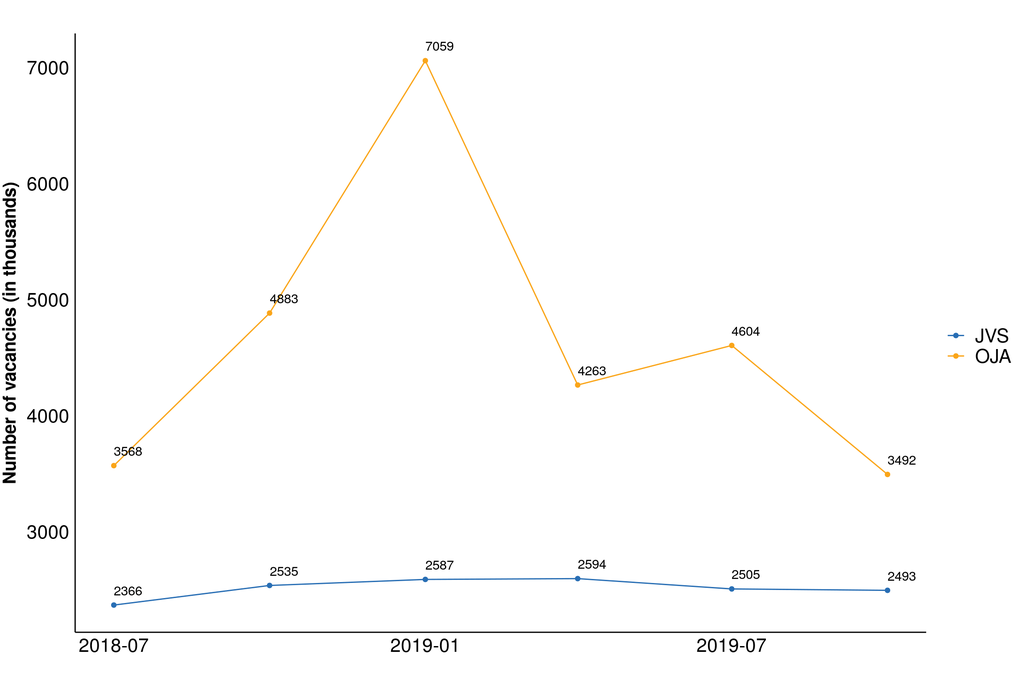

```r
# (relations1.jpeg) , out.width="1600px",out.height="829px"

MERGED_a %>%
filter(JVS > 0) %>%
select(-countries) %>%
group_by(time) %>%
summarise(across(.cols = everything(),~ sum(., na.rm = T))) %>%
gather(datasources, value, c(OJA, JVS)) %>%
ggplot() +
geom_line(aes(x = time, y = round(value/1000), colour = datasources, group=datasources)) +
geom_point(aes(x = time, y = round(value/1000), colour = datasources)) +
scale_colour_manual(values = c("#286EB4","#FAA519"), name = "") +
geom_text(aes(label = round(value/1000), x = time, y = round(value/1000)), hjust = 0, vjust = -1 ) +
theme_bw() +
labs(title = "",
     x = "",
     y = "Number of vacancies (in thousands)") +
theme(title = element_text(face = "bold", size = 15),
      axis.text.x = element_text(colour = "black", size = 16),
      axis.text.y = element_text(colour = "black", size = 16),
      axis.title.y = element_text(vjust = 2),
      legend.text=element_text(size = 16),
      axis.ticks = element_blank(),
      panel.grid = element_blank(),
      panel.border = element_blank(),
      axis.line = element_line(colour = "black"))
```

# Figure 3

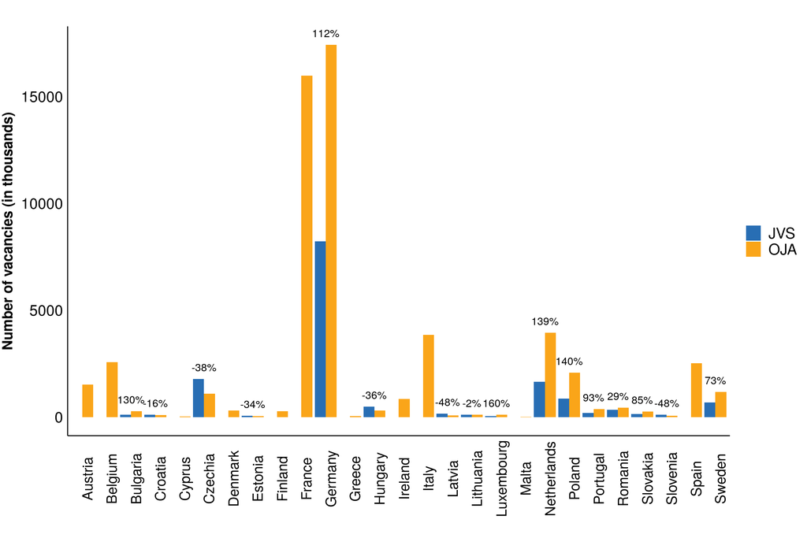

```r
# (relations3.png)

MERGED_a %>%
select(-time) %>%
group_by(countries) %>%
summarise(across(.cols = everything(),~ sum(., na.rm = T))) -> df -> df_plot
df <- df %>%
mutate(val = ifelse(JVS != 0, round(((OJA - JVS)/JVS)*100), NA),
       maxval = ifelse(OJA > JVS, OJA, JVS)) %>%
filter(!is.na(val))


df_plot %>%
gather(datasources, value, 2:3) %>%
mutate(value = ifelse(value == 0, NA, value),
       countries = as.factor(countries)) %>%
ggplot(aes(x = countries, y = value/1000)) +
geom_bar(aes(fill = datasources), stat = "identity", position = "dodge") +
geom_text(data = df, aes(label = paste0(val, "%"),
                         x = countries,
                         y = maxval/1000, hjust = 0.5, vjust = -1 ), size = 4) +
theme_bw() +
scale_fill_manual(values = c("#286EB4","#FAA519"), name = "") +
labs(title = "",
     x = "",
     y = "Number of vacancies (in thousands)") +
theme(title = element_text(face = "bold", size = 15),
      axis.text.x = element_text(colour = "black", size = 15, angle = 90),
      axis.text.y = element_text(colour = "black", size = 16),
      axis.title.y = element_text(vjust = 2),
      legend.text=element_text(size = 16),
      axis.ticks = element_blank(),
      panel.grid = element_blank(),
      panel.border = element_blank(),
      axis.line = element_line(colour = "black"))
```

# Figure 4

Number of job ads from OJA data and vacancies from JVS in countries over time

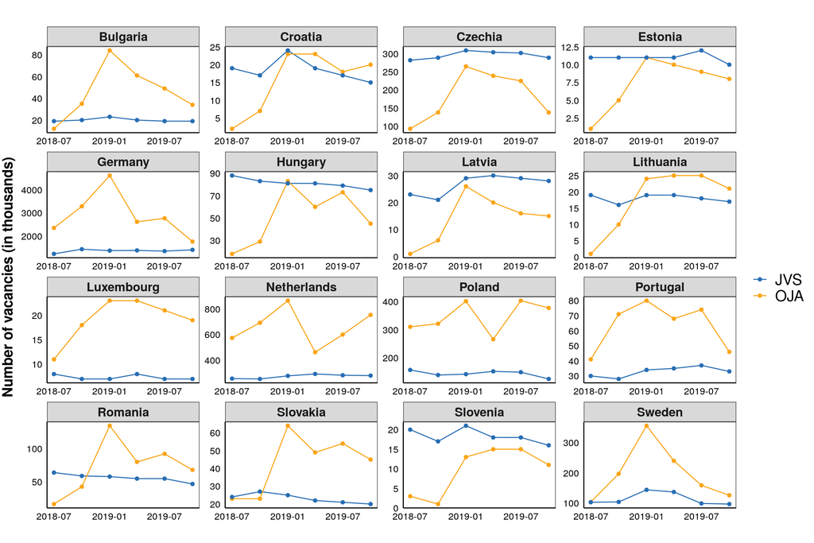

```r
# (relations4.jpeg)
MERGED_a %>%
filter(JVS > 0) %>%
gather(datasources, value, c(OJA, JVS)) %>%
ggplot() +
geom_line(aes(x = time, y = round(value/1000), colour = datasources)) +
geom_point(aes(x = time, y = round(value/1000), colour = datasources)) +
scale_colour_manual(values = c("#286EB4","#FAA519"), name = "") +
theme_bw() +
labs(title = "",
     x = "",
     y = "Number of vacancies (in thousands)") +
facet_wrap(~countries, ncol = 4, scales = "free") +
theme(title = element_text(face = "bold", size = 15),
      axis.text.x = element_text(colour = "black", size = 10),
      axis.text.y = element_text(colour = "black", size = 10),
      axis.title.y = element_text(vjust = 2),
      legend.text=element_text(size = 16),
      axis.ticks = element_blank(),
      panel.grid = element_blank(),
      strip.text = element_text(face = "bold", size = 13),
      axis.line = element_line(colour = "black"))
```

# Table 6

Descriptive statistics for OJA data and JVS - countries and time

```r
MERGED_a %>%
filter(JVS > 0) %>%
select(OJA,JVS) %>%
stat.desc()
```

```
##                              OJA                 JVS
## nbr.val                96.000000           96.000000
## nbr.null                0.000000            0.000000
## nbr.na                  0.000000            0.000000
## min                   708.000000         6899.000000
## max               4607939.000000      1442440.000000
## range             4607231.000000      1435541.000000
## sum              27869238.000000     15080160.000000
## median              45378.000000        29603.500000
## mean               290304.562500       157085.000000
## SE.mean             74932.356109        33447.530191
## CI.mean.0.95       148759.535160        66401.742876
## var          539026367232.606567 107398778482.000000
## std.dev            734184.150764       327717.528494
## coef.var                2.529013            2.086243
```

# Figure 5

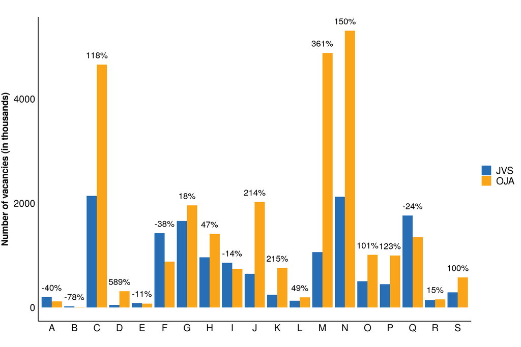

```r
# (relations9.png)

MERGED_b %>%
filter(countries %in% c("Bulgaria", "Croatia", "Czechia", "Germany", "Hungary",
                        "Latvia", "Lithuania", "Luxembourg", "Netherlands", "Poland",
                        "Romania", "Slovakia", "Sweden")) %>%
select(-c(countries, time)) %>%
group_by(nace_r2) %>%
summarise(across(.cols = everything(),~ sum(., na.rm = T))) -> df -> df_plot
df <- df %>%
mutate(val = round(((OJA - JVS)/JVS)*100),
       maxval = ifelse(OJA > JVS, OJA, JVS))


df_plot %>%
gather(datasources, value, c(OJA, JVS)) %>%
ggplot(aes(x = nace_r2, y = value/1000)) +
geom_bar(aes(fill = datasources), stat = "identity", position = "dodge") +
geom_text(data = df, aes(label = paste0(val, "%"),
                         x = nace_r2,
                         y = maxval/1000, hjust = 0.5, vjust = -1 ), size = 5) +
theme_bw() +
scale_fill_manual(values = c("#286EB4","#FAA519"), name = "") +
labs(title = "",
     x = "",
     y = "Number of vacancies (in thousands)") +
theme(title = element_text(face = "bold", size = 15),
      axis.text.x = element_text(colour = "black", size = 16),
      axis.text.y = element_text(colour = "black", size = 16),
      axis.title.y = element_text(vjust = 2),
      legend.text=element_text(size = 16),
      axis.ticks = element_blank(),
      panel.grid = element_blank(),
      panel.border = element_blank(),
      axis.line = element_line(colour = "black"))
```

# Figure 6

Number of job ads from OJA and vacancies from JVS in NACE sections over time

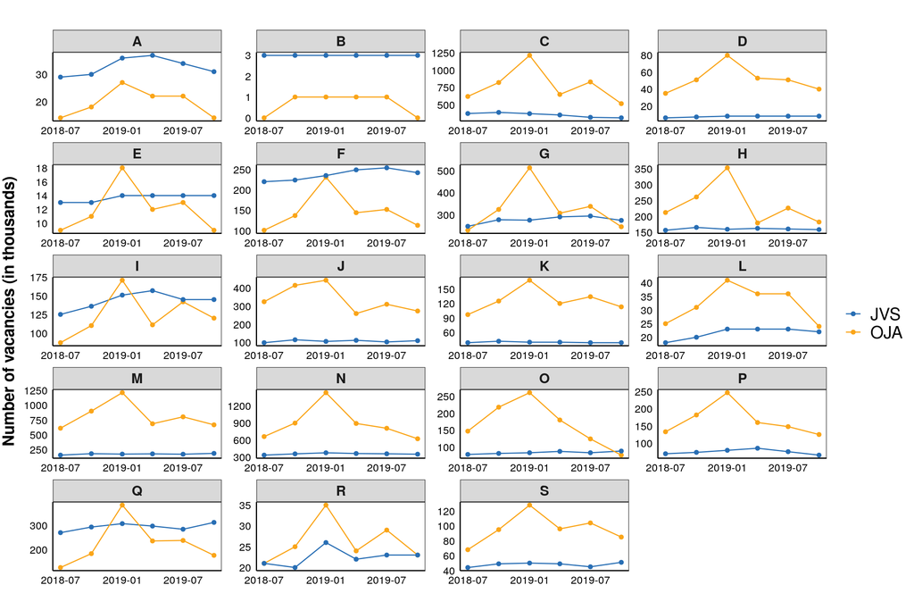

```r
# (relations10.jpeg)

MERGED_b %>%
filter(countries %in% c("Bulgaria", "Croatia", "Czechia", "Germany", "Hungary",
                        "Latvia", "Lithuania", "Luxembourg", "Netherlands", "Poland",
                        "Romania", "Slovakia", "Sweden")) %>%
select(-countries) %>%
group_by(time, nace_r2) %>%
summarise(across(.cols = everything(),~ sum(., na.rm = T))) %>%
gather(datasources, value, c(OJA, JVS)) %>%
ggplot() +
geom_line(aes(x = time, y = round(value/1000), colour = datasources)) +
geom_point(aes(x = time, y = round(value/1000), colour = datasources)) +
scale_colour_manual(values = c("#286EB4","#FAA519"), name = "") +
theme_bw() +
labs(title = "",
     x = "",
     y = "Number of vacancies (in thousands)") +
facet_wrap(~nace_r2, ncol = 4, scales = "free") +
theme(title = element_text(face = "bold", size = 15),
      axis.text.x = element_text(colour = "black", size = 10),
      axis.text.y = element_text(colour = "black", size = 10),
      axis.title.y = element_text(vjust = 2),
      legend.text=element_text(size = 16),
      axis.ticks = element_blank(),
      panel.grid = element_blank(),
      strip.text = element_text(face = "bold", size = 13),
      axis.line = element_line(colour = "black"))
```

# Table 7

Descriptive statistics for OJA data and JVS - NACE section and time

```r
MERGED_b %>%
filter(countries %in% c("Bulgaria", "Croatia", "Czechia", "Germany", "Hungary",
                        "Latvia", "Lithuania", "Luxembourg", "Netherlands", "Poland",
                        "Romania", "Slovakia", "Sweden")) %>%
select(-countries) %>%
group_by(time, nace_r2)  %>%
select(OJA,JVS) %>%
stat.desc()
```

```
##                            time nace_r2               OJA              JVS
## nbr.val          1482.000000000      NA       1482.000000      1482.000000
## nbr.null            0.000000000      NA         16.000000         4.000000
## nbr.na              0.000000000      NA          0.000000         0.000000
## min             17713.000000000      NA          0.000000         0.000000
## max             18170.000000000      NA     991253.000000    273314.000000
## range             457.000000000      NA     991253.000000    273314.000000
## sum          26589550.000000000      NA   27386400.000000  14705715.000000
## median          17942.000000000      NA       1291.000000      1513.500000
## mean            17941.666666667      NA      18479.352227      9922.884615
## SE.mean             4.049815468      NA       1839.526780       739.042707
## CI.mean.0.95        7.943984686      NA       3608.355167      1449.681842
## var             24306.289894216      NA 5014878703.084496 809444869.769932
## std.dev           155.904746221      NA      70815.808285     28450.744626
## coef.var            0.008689535      NA          3.832159         2.867185
```

# Figure 7

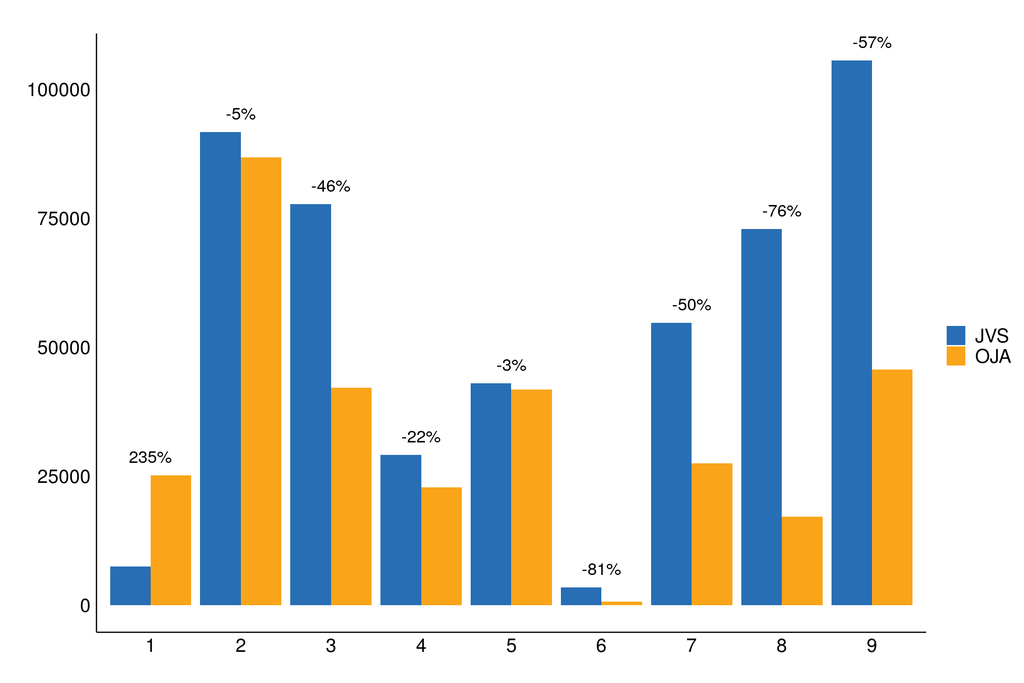

```r
# (relations14.png)

MERGED_c %>%
filter(countries == "Hungary") %>%
select(-c(countries, time)) %>%
group_by(isco08) %>%
summarise(across(.cols = everything(),~ sum(., na.rm = T))) -> df -> df_plot
df <- df %>%
mutate(val = round(((OJA - JVS)/JVS)*100),
       maxval = ifelse(OJA > JVS, OJA, JVS))

df_plot %>%
gather(datasources, value, 2:3) %>%
mutate(isco08 = factor(isco08),
       datasources = factor(datasources)) %>%
ggplot(aes(x = isco08, y = value)) +
geom_bar(aes(fill = datasources), stat = "identity", position = "dodge") +
geom_text(data = df, aes(label = paste0(val, "%"),
                         x = isco08,
                         y = maxval, hjust = 0.5, vjust = -1 ), size = 5) +
theme_bw() +
scale_fill_manual(values = c("#286EB4","#FAA519"), name = "") +
labs(title = "",
     x = "",
     y = "") +
theme(title = element_text(face = "bold", size = 15),
      axis.text.x = element_text(colour = "black", size = 16),
      axis.text.y = element_text(colour = "black", size = 16),
      axis.title.y = element_text(vjust = 2),
      legend.text=element_text(size = 16),
      axis.ticks = element_blank(),
      panel.grid = element_blank(),
      panel.border = element_blank(),
      axis.line = element_line(colour = "black"))
```

# Figure 8

Number of job ads from Cedefop and vacancies from Eurostat for ISCO major groups of occupations in Hungary over time

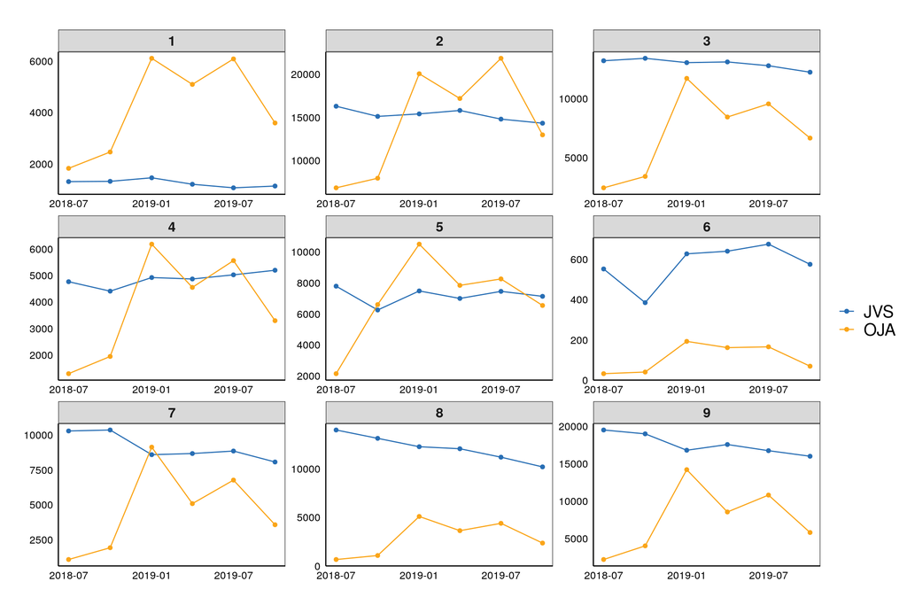

```r
# (relations15.jpeg)

MERGED_c %>%
filter(countries == "Hungary") %>%
select(-countries) %>%
group_by(isco08, time) %>%
summarise(across(.cols = everything(),~ sum(., na.rm = T))) %>%
gather(datasources, value, c(OJA, JVS)) %>%
ggplot() +
geom_line(aes(x = time, y = value, colour = datasources)) +
geom_point(aes(x = time, y = value, colour = datasources)) +
scale_colour_manual(values = c("#286EB4","#FAA519"), name = "") +
theme_bw() +
labs(title = "",
     x = "",
     y = "") +
facet_wrap(~isco08, ncol = 3, scales = "free") +
theme(title = element_text(face = "bold", size = 15),
      axis.text.x = element_text(colour = "black", size = 10),
      axis.text.y = element_text(colour = "black", size = 10),
      axis.title.y = element_text(vjust = 2),
      legend.text=element_text(size = 16),
      axis.ticks = element_blank(),
      panel.grid = element_blank(),
      strip.text = element_text(face = "bold", size = 13),
      axis.line = element_line(colour = "black"))
```

# Table 8

Descriptive statistics for OJA and JVS data for Hungary - ISCO major groups of occupation and time

```r
MERGED_c %>%
filter(countries == "Hungary") %>%
select(-c(countries, time)) %>%
group_by(isco08) %>%
select(OJA,JVS) %>%
stat.desc()
```

```
##          isco08             OJA              JVS
## nbr.val      NA       54.000000       54.0000000
## nbr.null     NA        0.000000        0.0000000
## nbr.na       NA        0.000000        0.0000000
## min          NA       32.000000      384.0000000
## max          NA    21847.000000    19494.0000000
## range        NA    21815.000000    19110.0000000
## sum          NA   309670.000000   485825.0000000
## median       NA     5082.500000     8748.5000000
## mean         NA     5734.629630     8996.7592593
## SE.mean      NA      668.613687      786.6946012
## CI.mean      NA     1341.069225     1577.9095458
## var          NA 24140390.162124 33419973.3560447
## std.dev      NA     4913.287104     5781.0010687
## coef.var     NA        0.856775        0.6425648
```

# Figure 9

Regression fit between JVS and OJA

```r
geos <- MERGED_a

geos  %<>%
filter(countries %in% c("Bulgaria", "Croatia", "Czechia", "Estonia", "Germany",
                        "Hungary", "Latvia", "Lithuania", "Luxembourg", "Netherlands",
                        "Poland", "Portugal", "Romania", "Slovakia", "Slovenia", "Sweden"))

geos_t <- geos %>%
          select(-countries) %>%
          group_by(time) %>%
          summarise_all(funs(mean(., na.rm = T),
                              sum(., na.rm = T)))
cor(geos_t$OJA_sum, geos_t$JVS_sum)
```

```
## [1] 0.6157777
```

```r
# (relations2.png)

linear <- lm(JVS_sum ~ OJA_sum, data=geos_t)
summary(linear)
```

```
##
## Call:
## lm(formula = JVS_sum ~ OJA_sum, data = geos_t)
##
## Residuals:
##       1       2       3       4       5       6
## -105220   12151  -21183   95527   -6312   25037
##
## Coefficients:
##                  Estimate    Std. Error t value  Pr(>|t|)
## (Intercept) 2331179.58187  120329.36761  19.373 0.0000418 ***
## OJA_sum           0.03922       0.02509   1.563     0.193
## ---
## Signif. codes:  0 '***' 0.001 '**' 0.01 '*' 0.05 '.' 0.1 ' ' 1
##
## Residual standard error: 73250 on 4 degrees of freedom
## Multiple R-squared:  0.3792, Adjusted R-squared:  0.224
## F-statistic: 2.443 on 1 and 4 DF,  p-value: 0.1931
```

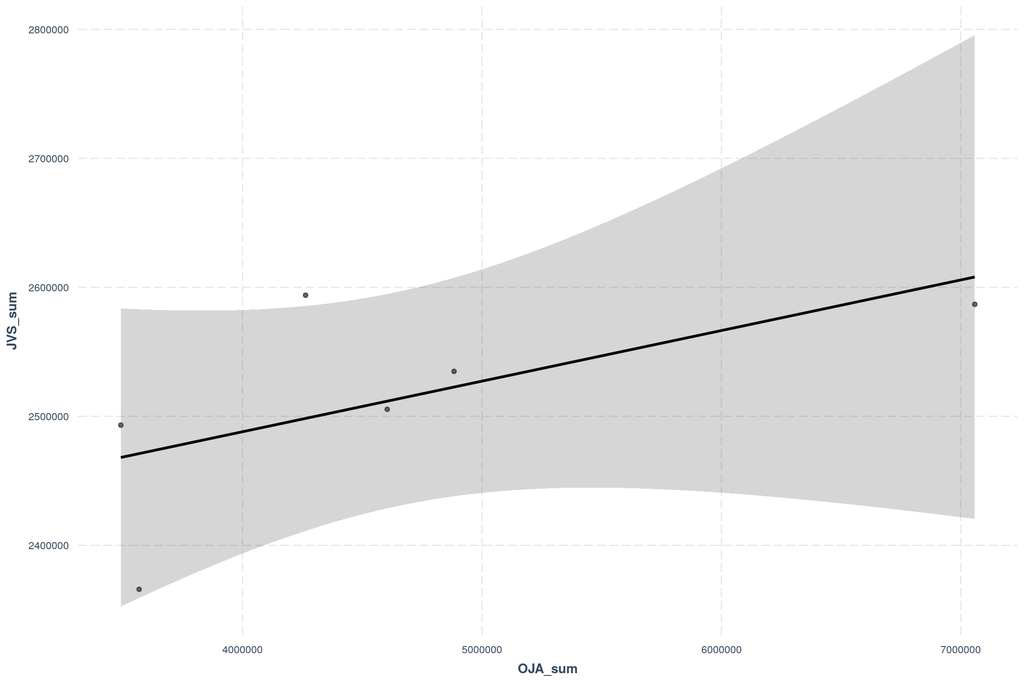

```r
effect_plot(linear, pred = OJA_sum, interval = TRUE, plot.points = TRUE)
```

# Figure 10

Regression results between OJA and JVS for individual countries

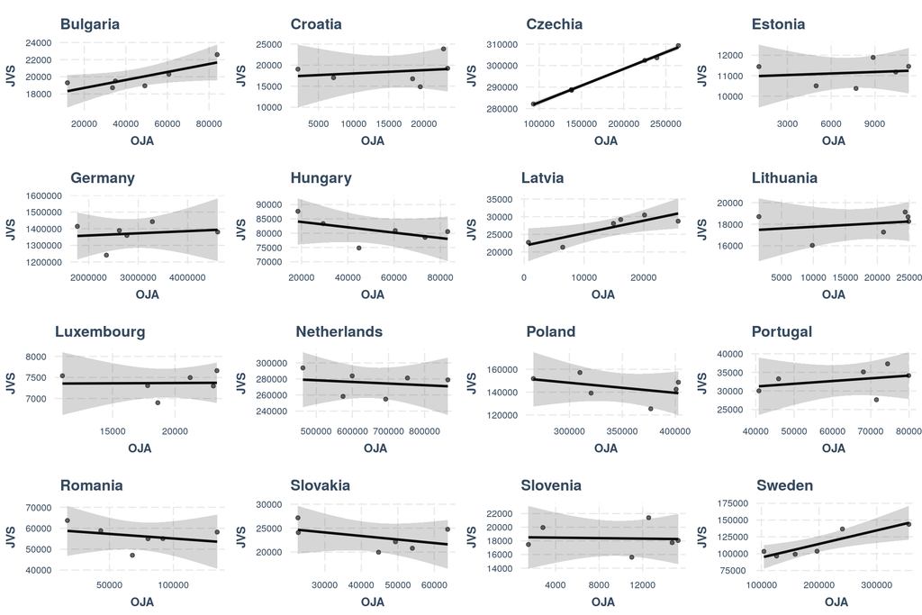

```r
# (relations8.jpeg)

df <- MERGED_a  %>%
filter(JVS > 0) %>%
mutate(time = as.character(time))

# custom function

lm_models <- lm_simulator(data = df,
                          dep_var = 4,
                          indep_var = 3,
                          key = 1)

lm_models_models <- lapply(1:16, function(x) lm_models$model_output[[x]]$model)
lm_models_models_plots <- lapply(1:16,  function(x){
  return(
    jtools::effect_plot(lm_models_models[[x]],
                        pred = OJA ,
                        interval = TRUE,
                        plot.points = TRUE,
                        main.title = names(lm_models$model_output[x]),
                        colors = "black")
  )
})


grid.arrange(lm_models_models_plots[[1]],
             lm_models_models_plots[[2]],
             lm_models_models_plots[[3]],
             lm_models_models_plots[[4]],
             lm_models_models_plots[[5]],
             lm_models_models_plots[[6]],
             lm_models_models_plots[[7]],
             lm_models_models_plots[[8]],
             lm_models_models_plots[[9]],
             lm_models_models_plots[[10]],
             lm_models_models_plots[[11]],
             lm_models_models_plots[[12]],
             lm_models_models_plots[[13]],
             lm_models_models_plots[[14]],
             lm_models_models_plots[[15]],
             lm_models_models_plots[[16]], ncol = 4)
```

# Table 9

Summary of regression results for individual countries

```r
lm_models_ols_coefficients <- lapply(1:16, function(x){
return(
cbind(x,
      round(lm_models$model_output[[x]]$intercept),
      format(round(lm_models$model_output[[x]]$beta, digits = 3), nsmall = 3),
      format(round(lm_models$model_output[[x]]$tstat, digits = 2), nsmall = 2),
      "adj.r2" =  format(round(lm_models$model_output[[x]]$adj_r2, digits = 2), nsmall = 2),
      "r2" =  format(round(lm_models$model_output[[x]]$r2, digits = 2), nsmall = 2),
      cbind("stat" = format(round(lm_models$model_output[[x]]$dwtest$statistic, digits = 1), nsmall = 1),
            "val" = lm_models$model_output[[x]]$dwtest$p.value)
      )
)});
lm_models_ols_coefficients <- do.call(rbind, lm_models_ols_coefficients)
lm_models_ols_coefficients
```

```
##             x    Intercept p.value Intercept p.value  (Intercept) OJA
## (Intercept) "1"  "17765"   "0"     "0.047"   "0.051"  "20.67"     " 2.77"
## (Intercept) "2"  "17238"   "0"     "0.079"   "0.670"  "5.75"      "0.46"
## (Intercept) "3"  "267277"  "0"     "0.156"   "0.000"  "325.47"    " 36.73"
## (Intercept) "4"  "10954"   "0"     "0.025"   "0.756"  "17.56"     " 0.33"
## (Intercept) "5"  "1333254" "0"     "0.013"   "0.731"  "12.44"     " 0.37"
## (Intercept) "6"  "85817"   "0"     "-0.094"  " 0.263" "21.07"     "-1.30"
## (Intercept) "7"  "21783"   "0"     "0.354"   "0.029"  "12.54"     " 3.32"
## (Intercept) "8"  "17433"   "0"     "0.033"   "0.592"  "15.53"     " 0.58"
## (Intercept) "9"  "7338"    "0"     "0.001"   "0.963"  "12.82"     " 0.05"
## (Intercept) "10" "288620"  "0"     "-0.020"  " 0.717" " 8.16"     "-0.39"
## (Intercept) "11" "174627"  "0"     "-0.088"  " 0.383" " 5.54"     "-0.98"
## (Intercept) "12" "28254"   "0"     "0.074"   "0.514"  "4.21"      "0.71"
## (Intercept) "13" "59478"   "0"     "-0.044"  " 0.534" "11.33"     "-0.68"
## (Intercept) "14" "26318"   "0"     "-0.074"  " 0.356" " 8.16"     "-1.04"
## (Intercept) "15" "18549"   "0"     "-0.018"  " 0.918" " 9.91"     "-0.11"
## (Intercept) "16" "74157"   "0"     "0.202"   "0.016"  "6.86"      "4.00"
##             adj.r2  r2     stat  val
## (Intercept) "0.57"  "0.66" "1.1" "0.0855977286838997"
## (Intercept) "-0.19" "0.05" "1.5" "0.119256807076848"
## (Intercept) "1.00"  "1.00" "3.3" "0.973721444152511"
## (Intercept) "-0.22" "0.03" "2.7" "0.673088682125396"
## (Intercept) "-0.21" "0.03" "2.1" "0.453779822122949"
## (Intercept) "0.12"  "0.30" "0.9" "0.0402126626326912"
## (Intercept) "0.67"  "0.73" "1.4" "0.128097633847903"
## (Intercept) "-0.15" "0.08" "2.7" "0.669329221270496"
## (Intercept) "-0.25" "0.00" "1.6" "0.169879140373523"
## (Intercept) "-0.20" "0.04" "0.8" "0.067786316255047"
## (Intercept) "-0.01" "0.19" "2.2" "0.761969283696143"
## (Intercept) "-0.11" "0.11" "1.2" "0.124201726089823"
## (Intercept) "-0.12" "0.10" "1.0" "0.0610903154170071"
## (Intercept) "0.02"  "0.21" "0.9" "0.0288166890857052"
## (Intercept) "-0.25" "0.00" "1.9" "0.266844935243344"
## (Intercept) "0.75"  "0.80" "2.6" "0.681369050645288"
```

# Figure 11

Regression results between OJA and JVS for individual economic activities

```r
# (relations13.jpeg)

df <- MERGED_b %>%
filter(countries %in% c("Bulgaria", "Croatia", "Czechia", "Germany", "Hungary",
                        "Latvia", "Lithuania", "Luxembourg", "Netherlands", "Poland",
                        "Romania", "Slovakia", "Sweden")) %>%
select(-countries) %>%
mutate(time = as.character(time)) %>%
group_by(time, nace_r2) %>%
summarise(across(.cols = everything(),~ sum(., na.rm = T))) %>%
ungroup() %>%
select(-time)
```

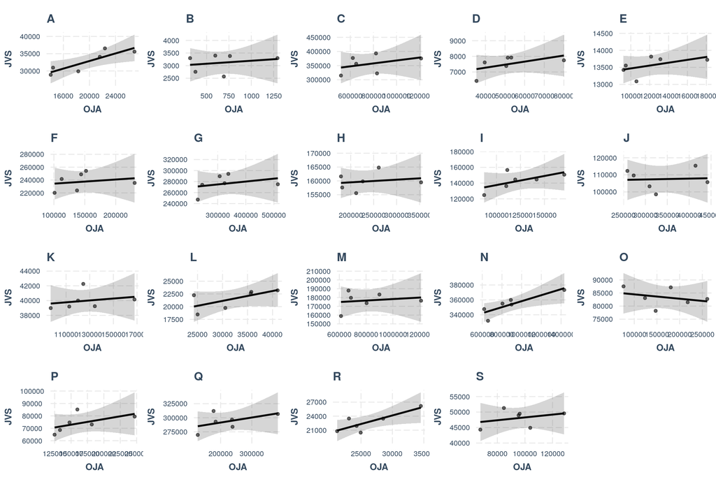

```r
# custom function

lm_models <- lm_simulator(data = df,
                          dep_var = 3,
                          indep_var = 2,
                          key = 1)

lm_models_models <- lapply(1:19, function(x) lm_models$model_output[[x]]$model)
lm_models_models_plots <- lapply(1:19,  function(x){
  return(
    jtools::effect_plot(lm_models_models[[x]],
                        pred = OJA ,
                        interval = TRUE,
                        plot.points = TRUE,
                        main.title = names(lm_models$model_output[x]),
                        colors = "black")
  )
})


grid.arrange(lm_models_models_plots[[1]],
             lm_models_models_plots[[2]],
             lm_models_models_plots[[3]],
             lm_models_models_plots[[4]],
             lm_models_models_plots[[5]],
             lm_models_models_plots[[6]],
             lm_models_models_plots[[7]],
             lm_models_models_plots[[8]],
             lm_models_models_plots[[9]],
             lm_models_models_plots[[10]],
             lm_models_models_plots[[11]],
             lm_models_models_plots[[12]],
             lm_models_models_plots[[13]],
             lm_models_models_plots[[14]],
             lm_models_models_plots[[15]],
             lm_models_models_plots[[16]],
             lm_models_models_plots[[17]],
             lm_models_models_plots[[18]],
             lm_models_models_plots[[19]], ncol = 5)
```

# Table 10

Summary of regression results for individual economic activities

```r
lm_models_ols_coefficients <- lapply(1:19, function(x){
return(
cbind(x,
      round(lm_models$model_output[[x]]$intercept),
      format(round(lm_models$model_output[[x]]$beta, digits = 3), nsmall = 3),
      format(round(lm_models$model_output[[x]]$tstat, digits = 2), nsmall = 2),
      "adj.r2" =  format(round(lm_models$model_output[[x]]$adj_r2, digits = 2), nsmall = 2),
      "r2" =  format(round(lm_models$model_output[[x]]$r2, digits = 2), nsmall = 2),
      cbind("stat" = format(round(lm_models$model_output[[x]]$dwtest$statistic, digits = 1), nsmall = 1),
            "val" = lm_models$model_output[[x]]$dwtest$p.value)
    )
)});
lm_models_ols_coefficients <- do.call(rbind, lm_models_ols_coefficients)
lm_models_ols_coefficients
```

```
##             x    Intercept p.value Intercept p.value  (Intercept) OJA
## (Intercept) "1"  "21864"   "0"     "0.551"   "0.027"  "6.75"      "3.42"
## (Intercept) "2"  "2957"    "0"     "0.237"   "0.659"  "7.98"      "0.48"
## (Intercept) "3"  "316245"  "0"     "0.052"   "0.429"  "6.63"      "0.88"
## (Intercept) "4"  "6495"    "0"     "0.019"   "0.269"  "7.98"      "1.28"
## (Intercept) "5"  "13048"   "0"     "0.042"   "0.296"  "29.83"     " 1.20"
## (Intercept) "6"  "227866"  "0"     "0.065"   "0.680"  "10.32"     " 0.44"
## (Intercept) "7"  "259065"  "0"     "0.053"   "0.528"  "10.04"     " 0.69"
## (Intercept) "8"  "157533"  "0"     "0.010"   "0.708"  "26.99"     " 0.40"
## (Intercept) "9"  "114445"  "0"     "0.231"   "0.210"  "5.86"      "1.49"
## (Intercept) "10" "105761"  "0"     "0.005"   "0.908"  "7.49"      "0.12"
## (Intercept) "11" "38355"   "0"     "0.013"   "0.629"  "12.22"     " 0.52"
## (Intercept) "12" "15309"   "0"     "0.194"   "0.153"  "4.26"      "1.76"
## (Intercept) "13" "169763"  "0"     "0.008"   "0.725"  "9.04"      "0.38"
## (Intercept) "14" "318075"  "0"     "0.040"   "0.028"  "28.86"     " 3.37"
## (Intercept) "15" "86155"   "0"     "-0.017"  " 0.546" "19.08"     "-0.66"
## (Intercept) "16" "59370"   "0"     "0.090"   "0.258"  "5.08"      "1.32"
## (Intercept) "17" "273620"  "0"     "0.089"   "0.300"  "15.29"     " 1.19"
## (Intercept) "18" "13144"   "0"     "0.367"   "0.041"  "4.01"      "2.96"
## (Intercept) "19" "43706"   "0"     "0.046"   "0.525"  "6.82"      "0.70"
##             adj.r2  r2     stat  val
## (Intercept) "0.68"  "0.75" "1.5" "0.18327317557032"
## (Intercept) "-0.18" "0.05" "0.8" "0.0379750443400424"
## (Intercept) "-0.05" "0.16" "0.8" "0.0538113643602378"
## (Intercept) "0.11"  "0.29" "0.9" "0.0590784281900609"
## (Intercept) "0.08"  "0.26" "1.4" "0.19821788792277"
## (Intercept) "-0.19" "0.05" "0.6" "0.0235194435886886"
## (Intercept) "-0.12" "0.11" "1.4" "0.171483415378285"
## (Intercept) "-0.20" "0.04" "2.8" "0.925724419934665"
## (Intercept) "0.20"  "0.36" "2.0" "0.496599854346859"
## (Intercept) "-0.25" "0.00" "2.9" "0.888233971228125"
## (Intercept) "-0.17" "0.06" "2.4" "0.686700079745189"
## (Intercept) "0.30"  "0.44" "0.5" "0.0087001627388963"
## (Intercept) "-0.21" "0.03" "1.9" "0.433501409279833"
## (Intercept) "0.67"  "0.74" "0.9" "0.0646386508789736"
## (Intercept) "-0.13" "0.10" "1.3" "0.0920498047652739"
## (Intercept) "0.13"  "0.30" "1.8" "0.310194754617664"
## (Intercept) "0.08"  "0.26" "1.9" "0.358542477755251"
## (Intercept) "0.61"  "0.69" "1.7" "0.315707264929217"
## (Intercept) "-0.11" "0.11" "2.6" "0.720054702159989"
```

# Table 11 and Figure 12

Panel data regression between OJA and JVS - countries — and — Time effects for the fixed effects regression between OJA and JVS

```r
geos <- MERGED_a
geos[geos == 0] <- NA

geos  %>%
  filter(countries %in% c("Bulgaria", "Croatia", "Czechia", "Estonia", "Germany",
                          "Hungary", "Latvia", "Lithuania", "Luxembourg", "Netherlands",
                          "Poland", "Portugal", "Romania", "Slovakia", "Slovenia", "Sweden")) -> geos

geos_t <- geos %>%
  select(-countries) %>%
  group_by(time) %>%
  summarise_all(funs(mean(., na.rm = T),
                      sum(., na.rm = T)))

geos_t$rel <- (geos_t$OJA_mean - geos_t$JVS_mean) / geos_t$JVS_mean

geos_s <- geos %>%
  select(-time) %>%
  group_by(countries) %>%
  summarise_all(funs(mean(., na.rm = T),
                      sum(., na.rm = T)))

geos_s$rel <- (geos_s$OJA_mean - geos_s$JVS_mean) / geos_s$JVS_mean

geos <- pdata.frame(geos, index=c("countries","time"), stringsAsFactors = TRUE)

panel1 <- plm(JVS ~ OJA, data=geos, model="within", effect = "twoways")
summary(panel1)
```

```
## Twoways effects Within Model
##
## Call:
## plm(formula = JVS ~ OJA, data = geos, effect = "twoways", model = "within")
##
## Balanced Panel: n = 16, T = 6, N = 96
##
## Residuals:
##      Min.   1st Qu.    Median   3rd Qu.      Max.
## -115702.9   -4797.8   -1245.3    3566.0   65904.6
##
## Coefficients:
##      Estimate Std. Error t-value Pr(>|t|)
## OJA 0.0111783  0.0090608  1.2337   0.2212
##
## Total Sum of Squares:    27333000000
## Residual Sum of Squares: 26782000000
## R-Squared:      0.020154
## Adj. R-Squared: -0.25791
## F-statistic: 1.52204 on 1 and 74 DF, p-value: 0.22122
```

```r
pdwtest(panel1)
```

```
##
##  Durbin-Watson test for serial correlation in panel models
##
## data:  JVS ~ OJA
## DW = 2.6053, p-value = 0.9988
## alternative hypothesis: serial correlation in idiosyncratic errors
```

```r
fixed <- fixef(panel1, effect = "time")
fixef(panel1, effect = "individual")
```

```
##    Bulgaria     Croatia     Czechia     Estonia     Germany     Hungary
##     19383.1     18285.2    293761.4     11059.2   1338622.1     80395.1
##      Latvia   Lithuania  Luxembourg Netherlands      Poland    Portugal
##     26591.3     17816.5      7151.8    267790.3    140250.1     32210.0
##     Romania    Slovakia    Slovenia      Sweden
##     55488.5     22673.1     18264.0    111696.3
```

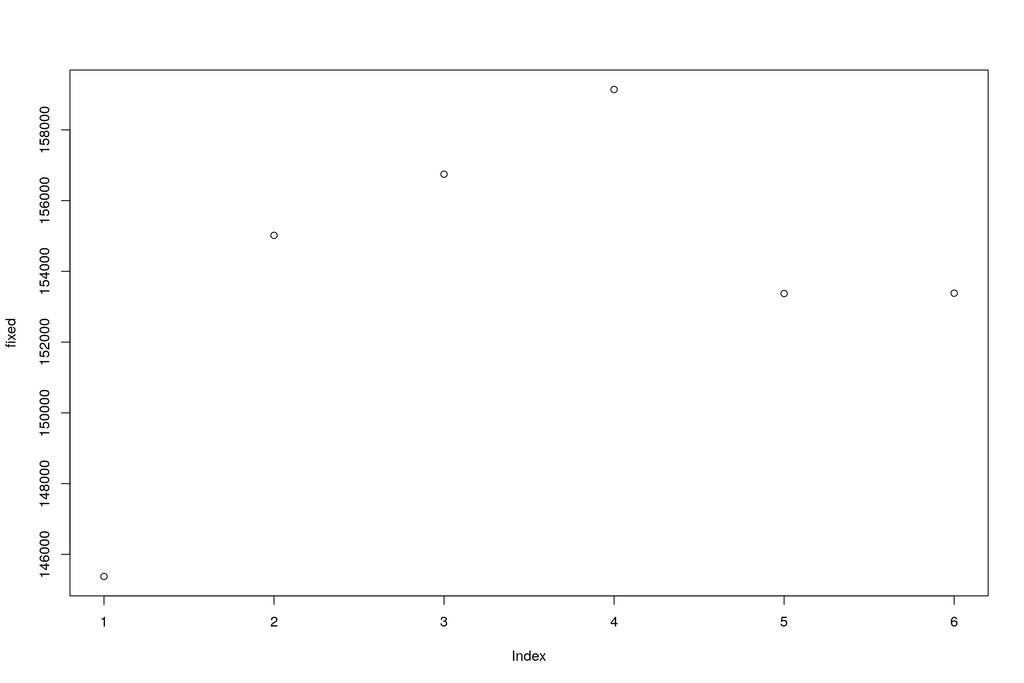

```r
plot(fixed)
```

```r
panel2 <- plm(JVS ~ OJA, data=geos, model="random", effect = "twoways")
summary(panel2)
```

```
## Twoways effects Random Effect Model
##    (Swamy-Arora's transformation)
##
## Call:
## plm(formula = JVS ~ OJA, data = geos, effect = "twoways", model = "random")
##
## Balanced Panel: n = 16, T = 6, N = 96
##
## Effects:
##                      var    std.dev share
## idiosyncratic  361921944      19024 0.106
## individual    3040248937      55138 0.894
## time                   0          0 0.000
## theta: 0.8605 (id) 0 (time) 0 (total)
##
## Residuals:
##     Min.  1st Qu.   Median  3rd Qu.     Max.
## -23694.2 -17093.5 -14125.7  -3384.3 276568.4
##
## Coefficients:
##                  Estimate    Std. Error z-value    Pr(>|z|)
## (Intercept) 132890.640027  33059.832110  4.0197 0.000058272 ***
## OJA              0.083341      0.018447  4.5179 0.000006247 ***
## ---
## Signif. codes:  0 '***' 0.001 '**' 0.01 '*' 0.05 '.' 0.1 ' ' 1
##
## Total Sum of Squares:    227410000000
## Residual Sum of Squares: 186840000000
## R-Squared:      0.1784
## Adj. R-Squared: 0.16966
## Chisq: 20.4111 on 1 DF, p-value: 0.0000062468
```

```r
pdwtest(panel2)
```

```
##
##  Durbin-Watson test for serial correlation in panel models
##
## data:  JVS ~ OJA
## DW = 1.0048, p-value = 0.00000007197
## alternative hypothesis: serial correlation in idiosyncratic errors
```

```r
phtest(panel1,panel2)
```

```
##
##  Hausman Test
##
## data:  JVS ~ OJA
## chisq = 20.169, df = 1, p-value = 0.000007091
## alternative hypothesis: one model is inconsistent
```

```r
ranef(panel2)
```

```
##    Bulgaria     Croatia     Czechia     Estonia     Germany     Hungary
##  -114533.24  -113476.86   144785.85  -119984.29   976979.90   -55126.29
##      Latvia   Lithuania  Luxembourg Netherlands      Poland    Portugal
##  -105223.17  -114089.93  -124649.64    85738.16   -17280.23  -103210.73
##     Romania    Slovakia    Slovenia      Sweden
##   -81021.60  -111104.86  -113078.91   -34724.15
```

```r
panel3 <- plm(JVS ~ OJA, data=geos, model="fd", effect = "individual")
summary(panel3)
```

```
## Oneway (individual) effect First-Difference Model
##
## Call:
## plm(formula = JVS ~ OJA, data = geos, effect = "individual",
##     model = "fd")
##
## Balanced Panel: n = 16, T = 6, N = 96
## Observations used in estimation: 80
##
## Residuals:
##      Min.   1st Qu.    Median   3rd Qu.      Max.
## -70124.22  -4545.87  -2686.00   -645.54 195557.14
##
## Coefficients:
##                 Estimate   Std. Error t-value Pr(>|t|)
## (Intercept) 1595.3420265 2947.4020854  0.5413   0.5899
## OJA            0.0048304    0.0093216  0.5182   0.6058
##
## Total Sum of Squares:    54394000000
## Residual Sum of Squares: 54208000000
## R-Squared:      0.0034308
## Adj. R-Squared: -0.0093457
## F-statistic: 0.268526 on 1 and 78 DF, p-value: 0.60579
```

```r
pdwtest(panel3)
```

```
##
##  Durbin-Watson test for serial correlation in panel models
##
## data:  JVS ~ OJA
## DW = 2.6475, p-value = 0.9987
## alternative hypothesis: serial correlation in idiosyncratic errors
```

# Figure 13

Fixed effects regression between OJA and JVS with increasing time span

```r
# countries over the time
df_countries <- MERGED_a %>%
                filter(JVS > 0)

unique_time <- unique(df_countries$time)
models_countries <- lapply(2:length(unique(df_countries$time)) , function(x){
sample <- df_countries[df_countries$time %in% unique_time[1:x],]
m <- plm("JVS ~ OJA", data = sample, index = c("countries", "time"), effect = "twoways", model = "within")
fixef <- fixef(m)
beta <- m$coefficients
return(list("model" = m, "beta" = beta, "fixedeffect" = fixef))
}); names(models_countries) <- paste0(2:length(unique(df_countries$time)), " years", sep = "")
# objects in list: 1 - model, 2 - only beta's, 3 - vector of fixed effect for the entire list of countries

# NACE over the time
df_nace <- MERGED_b %>%
filter(countries %in% c("Bulgaria", "Croatia", "Czechia", "Germany", "Hungary",
                        "Latvia", "Lithuania", "Luxembourg", "Netherlands", "Poland",
                        "Romania", "Slovakia", "Sweden")) %>%
select(-countries) %>%
group_by(nace_r2, time) %>%
summarise(across(.cols = everything(),~ sum(., na.rm = T))) %>%
ungroup()
```

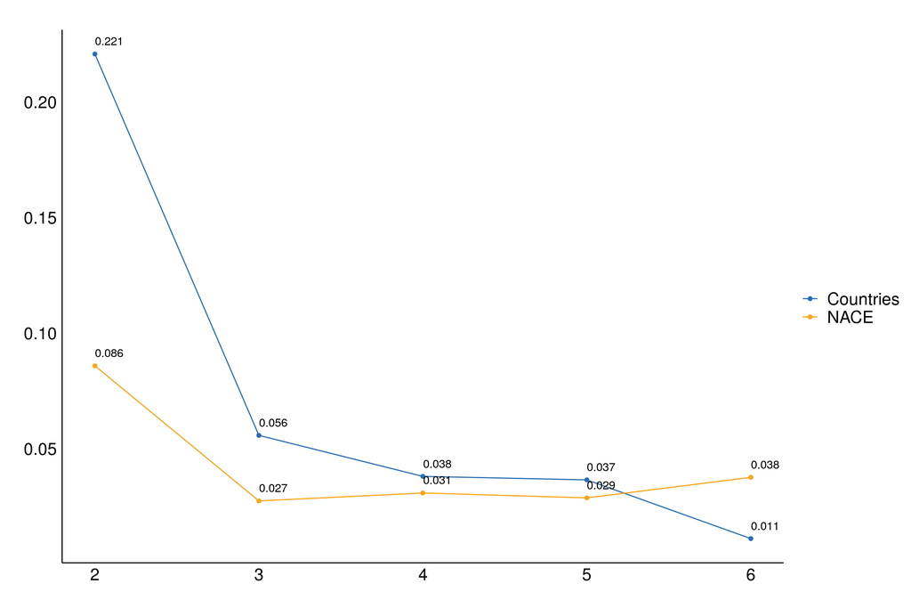

```r
unique_time <- unique(df_nace$time)
models_nace <- lapply(2:length(unique(df_nace$time)) , function(x){
sample <- df_nace[df_nace$time %in% unique_time[1:x],]
m <- plm("JVS ~ OJA", data = sample, index = c("nace_r2", "time"), effect = "twoways", model = "within")
fixef <- fixef(m)
beta <- m$coefficients
return(list("model" = m, "beta" = beta, "fixedeffect" = fixef))
}); names(models_nace) <- paste0(2:length(unique(df_nace$time)), " years", sep = "")
# objects in list: 1 - model, 2 - only beta's, 3 - vector of fixed effect for the entire list of countries


# merge models
df_countries <- lapply(1:length(models_countries),
                       function(x) models_countries[[x]]$beta); df_countries <- do.call(rbind, df_countries)
df_countries  <- cbind(seq(2,6,1), df_countries)
df_nace <- lapply(1:length(models_nace),
                  function(x) models_nace[[x]]$beta); df_nace <- do.call(rbind, df_nace)
df_nace  <- cbind(seq(2,6,1), df_nace)

df <- cbind(df_countries,df_nace[,2]) %>% data.frame()
colnames(df) <- c("index", "Countries", "NACE")

# Fixed effects regression between OJA and JVS with increasing time span
df %>%
gather(org, value, 2:3) %>%
ggplot() +
geom_line(aes(x = index, y = value, colour = org)) +
geom_point(aes(x = index, y = value, colour = org)) +
geom_text(aes(label = format(round(value, 3), nsmall = 3) , x = index, y = value), hjust = 0, vjust = -1 ) +
scale_colour_manual(values = c("#286EB4","#FAA519"), name = "") +
theme_bw() +
labs(title = "",
       x = "",
       y = "") +
theme(title = element_text(face = "bold", size = 15),
        axis.text.x = element_text(colour = "black", size = 16),
        axis.text.y = element_text(colour = "black", size = 16),
        axis.title.y = element_text(vjust = 2),
        legend.text=element_text(size = 16),
        axis.ticks = element_blank(),
        panel.grid = element_blank(),
        panel.border = element_blank(),
        axis.line = element_line(colour = "black"))
```

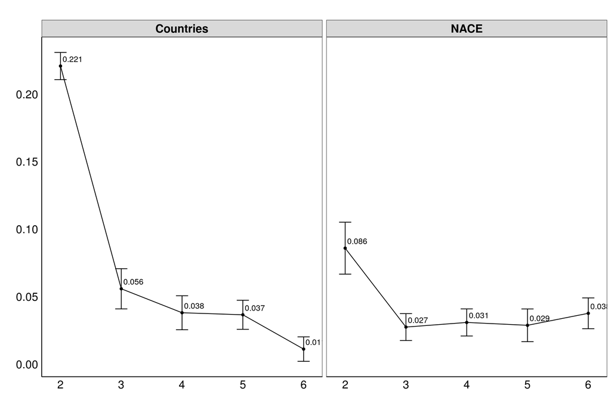

```r
# plot with error bars in file "plm models.R"
# (relations6.jpeg)

df_countries <- MERGED_a %>%
                filter(JVS > 0)

unique_time <- unique(df_countries$time)
models_countries <- lapply(2:length(unique(df_countries$time)) , function(x){
 sample <- df_countries[df_countries$time %in% unique_time[1:x],]
 m <- plm("JVS ~ OJA", data = sample, index = c("countries", "time"), effect = "twoways", model = "within")
 fixef <- fixef(m)
 beta <- m$coefficients
 se <- summary(m)$coefficients[2]
 return(list("model" = m, "beta" = beta, "se" = se, "fixedeffect" = fixef))
}); names(models_countries) <- paste0(2:length(unique(df_countries$time)), " years", sep = "")
# objects in list: 1 - model, 2 - only beta's, 3 - vector of fixed effect for the entire list of countries

# NACE over the time
df_nace <- MERGED_b %>%
 filter(countries %in% c("Bulgaria", "Croatia", "Czechia", "Germany", "Hungary",
                         "Latvia", "Lithuania", "Luxembourg", "Netherlands", "Poland",
                         "Romania", "Slovakia", "Sweden")) %>%
 select(-countries) %>%
 group_by(nace_r2, time) %>%
 summarise_each(funs(sum(., na.rm = T))) %>%
 ungroup()
unique_time <- unique(df_nace$time)
models_nace <- lapply(2:length(unique(df_nace$time)) , function(x){
 sample <- df_nace[df_nace$time %in% unique_time[1:x],]
 m <- plm("JVS ~ OJA", data = sample, index = c("nace_r2", "time"), effect = "twoways", model = "within")
 fixef <- fixef(m)
 beta <- m$coefficients
 se <- summary(m)$coefficients[2]
 return(list("model" = m, "beta" = beta, "se" = se, "fixedeffect" = fixef))
}); names(models_nace) <- paste0(2:length(unique(df_nace$time)), " years", sep = "")
# objects in list: 1 - model, 2 - only beta's, 3 - vector of fixed effect for the entire list of countries



# merge models
df_countries <- lapply(1:length(models_countries), function(x){
 data.frame("beta" = models_countries[[x]]$beta,  "se" = models_countries[[x]]$se)
 }); df_countries <- do.call(rbind, df_countries)
df_countries  <- cbind("lp" = seq(2,6,1), df_countries, "Group" = "Countries")


df_nace <- lapply(1:length(models_nace), function(x) {
 data.frame("beta" = models_nace[[x]]$beta,  "se" = models_nace[[x]]$se)
  }); df_nace <- do.call(rbind, df_nace)
df_nace  <- cbind("lp" = seq(2,6,1), df_nace, "Group" = "NACE")

df <- rbind(df_countries, df_nace)
df <- df %>%
      select(1,4,2,3)

ggplot(df, aes(x = lp, y = beta)) +
 geom_line() +
 geom_point() +
 geom_errorbar(aes(ymin = beta - se, ymax = beta + se), width=.2,
               position = position_dodge()) +
 geom_text(aes(label = format(round(beta, 3), nsmall = 3) , x = lp, y = beta), hjust = -0.1, vjust = -0.7, size = 4) +
 facet_wrap(~Group, ncol = 2) +
 theme_bw() +
 labs(title = "",
       x = "",
       y = "") +
 theme(title = element_text(face = "bold", size = 15),
        axis.text.x = element_text(colour = "black", size = 16),
        axis.text.y = element_text(colour = "black", size = 16),
        axis.title.y = element_text(vjust = 2),
        legend.text=element_text(size = 16),
        axis.ticks = element_blank(),
        panel.grid = element_blank(),
        strip.text = element_text(colour = "black", size = 16, face = "bold"),
        axis.line = element_line(colour = "black"))
```

# Figure 14

Individual country effects in fixed effects regression between OJA and JVS with increasing time span

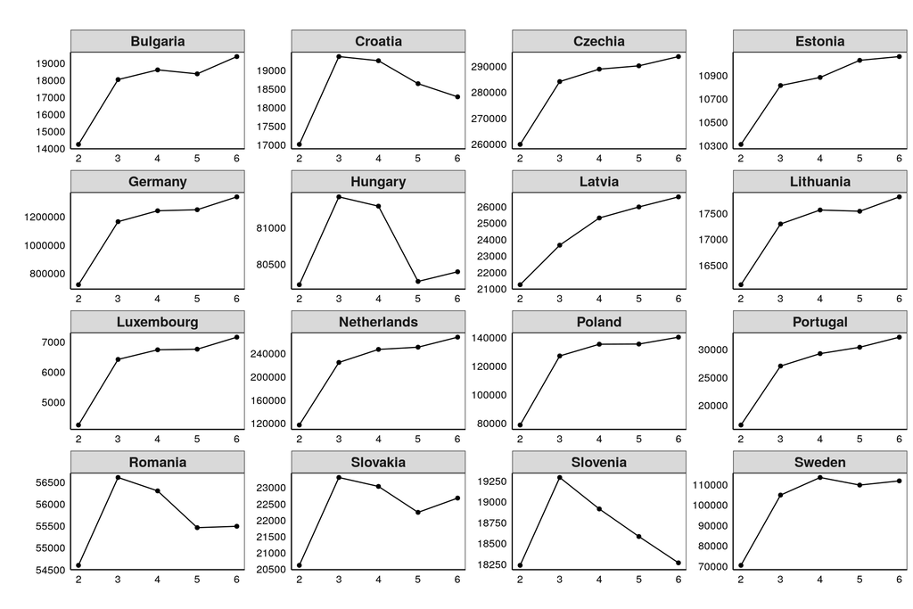

```r
# (relations7.jpeg)

df_countries_beta <- lapply(1:length(models_countries),
                     function(x) models_countries[[x]]$fixedeffect); df_countries_beta <- do.call(cbind, df_countries_beta)
df_countries_beta <- cbind(rownames(df_countries_beta), df_countries_beta) %>% data.frame()
colnames(df_countries_beta) <- c("countries", "2", "3", "4", "5", "6")

df_countries_beta %>%
gather(index, value, 2:6) %>%
mutate(countries = as.character(countries),
       index = as.numeric(index),
       value = as.numeric(value),
       value = round(value)) %>%
ggplot() +
geom_line(aes(x = index, y = value)) +
geom_point(aes(x = index, y = value)) +
theme_bw() +
labs(title = "",
       x = "",
       y = "") +
facet_wrap(~countries, ncol = 4, scales = "free") +
theme(title = element_text(face = "bold", size = 15),
      axis.text.x = element_text(colour = "black", size = 10),
      axis.text.y = element_text(colour = "black", size = 10),
      axis.title.y = element_text(vjust = 2),
      legend.text=element_text(size = 16),
      axis.ticks = element_blank(),
      panel.grid = element_blank(),
      strip.text = element_text(face = "bold", size = 13),
      axis.line = element_line(colour = "black"))
```

# Table 12 and Figure 15

Panel data regression between OJA and JVS - NACE sections  
—- and —- Time effects for the fixed effects regression between OJA and JVS

```r
nace <- MERGED_b

nace  %>%
  filter(countries %in% c("Bulgaria", "Croatia", "Czechia", "Germany",
                          "Hungary", "Latvia", "Lithuania", "Luxembourg", "Netherlands",
                          "Poland", "Romania", "Slovakia", "Sweden")) -> nace

nace2 <- nace %>%
  select(-countries) %>%
  group_by(nace_r2, time) %>%
  summarise_all(funs(sum(., na.rm = T))) %>%
  ungroup()

nace_s <- nace %>%
  select(-c(time, countries)) %>%
  group_by(nace_r2) %>%
  summarise_all(funs(mean(., na.rm = T),
                      sum(., na.rm = T)))


nace_s$rel <- (nace_s$OJA_mean - nace_s$JVS_mean) / nace_s$JVS_mean


nace <- pdata.frame(nace2, index=c("nace_r2","time"), stringsAsFactors = TRUE)

panel1 <- plm(JVS ~ OJA, data=nace, model="within", effect = "twoways")
summary(panel1)
```

```
## Twoways effects Within Model
##
## Call:
## plm(formula = JVS ~ OJA, data = nace, effect = "twoways", model = "within")
##
## Balanced Panel: n = 19, T = 6, N = 114
##
## Residuals:
##       Min.    1st Qu.     Median    3rd Qu.       Max.
## -35538.230  -2911.009     55.604   2862.069  33801.891
##
## Coefficients:
##     Estimate Std. Error t-value Pr(>|t|)
## OJA 0.037679   0.011408  3.3028 0.001379 **
## ---
## Signif. codes:  0 '***' 0.001 '**' 0.01 '*' 0.05 '.' 0.1 ' ' 1
##
## Total Sum of Squares:    9457600000
## Residual Sum of Squares: 8425000000
## R-Squared:      0.10919
## Adj. R-Squared: -0.13103
## F-statistic: 10.9088 on 1 and 89 DF, p-value: 0.0013793
```

```r
pdwtest(panel1)
```

```
##
##  Durbin-Watson test for serial correlation in panel models
##
## data:  JVS ~ OJA
## DW = 1.4487, p-value = 0.002103
## alternative hypothesis: serial correlation in idiosyncratic errors
```

```r
fixed <- fixef(panel1, effect = "time")
fixef(panel1, effect = "individual")
```

```
##        A        B        C        D        E        F        G        H
##  31923.5   3091.2 327265.5   5552.9  13101.4 231799.4 263904.0 150938.2
##        I        J        K        L        M        N        O        P
## 138260.7  94770.6  35222.0  20320.8 145996.1 320303.7  77039.8  68062.2
##        Q        R        S
## 285208.1  21739.4  44471.0
```

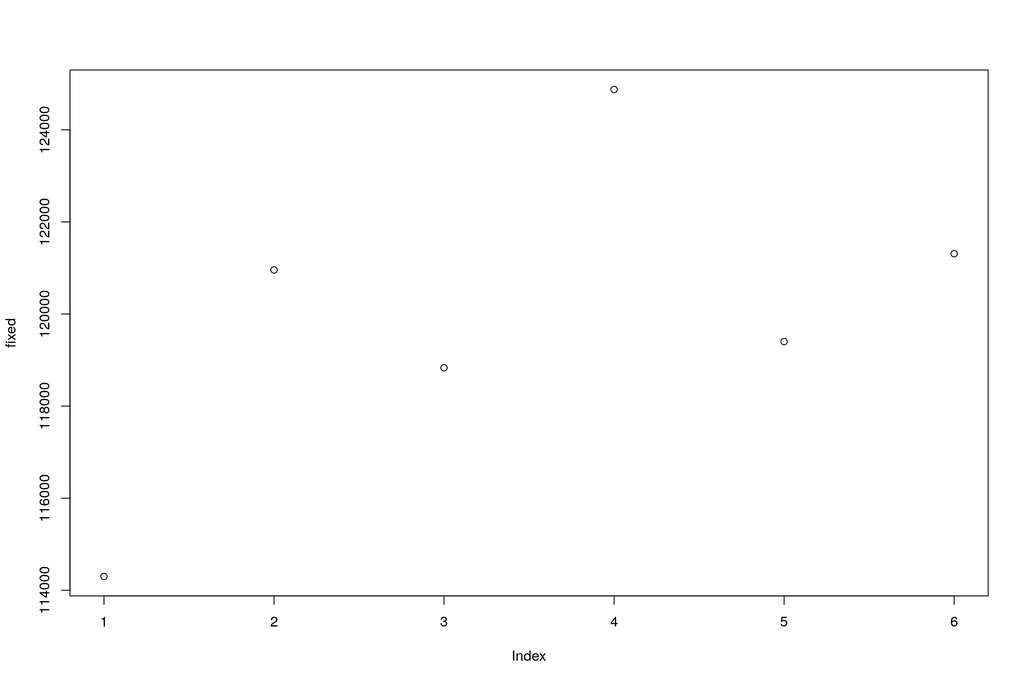

```r
plot(fixed)
```

```r
panel2 <- plm(JVS ~ OJA, data=nace, model="random", effect = "twoways")
summary(panel2)
```

```
## Twoways effects Random Effect Model
##    (Swamy-Arora's transformation)
##
## Call:
## plm(formula = JVS ~ OJA, data = nace, effect = "twoways", model = "random")
##
## Balanced Panel: n = 19, T = 6, N = 114
##
## Effects:
##                      var    std.dev share
## idiosyncratic   94662424       9730 0.015
## individual    6312013075      79448 0.984
## time            10166397       3188 0.002
## theta: 0.9501 (id) 0.4265 (time) 0.4264 (total)
##
## Residuals:
##     Min.  1st Qu.   Median  3rd Qu.     Max.
## -26071.7  -5880.2  -3206.7   3689.0  44269.3
##
## Coefficients:
##                  Estimate    Std. Error z-value       Pr(>|z|)
## (Intercept) 118286.130002  19796.033790  5.9752 0.000000002297 ***
## OJA              0.044588      0.011045  4.0369 0.000054166114 ***
## ---
## Signif. codes:  0 '***' 0.001 '**' 0.01 '*' 0.05 '.' 0.1 ' ' 1
##
## Total Sum of Squares:    13963000000
## Residual Sum of Squares: 12189000000
## R-Squared:      0.12702
## Adj. R-Squared: 0.11923
## Chisq: 16.2964 on 1 DF, p-value: 0.000054166
```

```r
pdwtest(panel2)
```

```
##
##  Durbin-Watson test for serial correlation in panel models
##
## data:  JVS ~ OJA
## DW = 1.1883, p-value = 0.000006313
## alternative hypothesis: serial correlation in idiosyncratic errors
```

```r
phtest(panel1,panel2)
```

```
##
##  Hausman Test
##
## data:  JVS ~ OJA
## chisq = 5.8567, df = 1, p-value = 0.01552
## alternative hypothesis: one model is inconsistent
```

```r
ranef(panel2)
```

```
##          A          B          C          D          E          F          G
##  -86282.42 -114912.38  203109.54 -112808.54 -105005.94  112221.91  143006.53
##          H          I          J          K          L          M          N
##   30947.75   19074.05  -25779.43  -83725.86  -97941.91   22032.93  195422.08
##          O          P          Q          R          S
##  -42299.10  -51240.09  164959.58  -96485.82  -74292.89
```

```r
panel3 <- plm(JVS ~ OJA, data=nace, model="fd", effect = "individual")
summary(panel3)
```

```
## Oneway (individual) effect First-Difference Model
##
## Call:
## plm(formula = JVS ~ OJA, data = nace, effect = "individual",
##     model = "fd")
##
## Balanced Panel: n = 19, T = 6, N = 114
## Observations used in estimation: 95
##
## Residuals:
##     Min.  1st Qu.   Median  3rd Qu.     Max.
## -38206.3  -4077.2  -1077.0   4164.4  27650.0
##
## Coefficients:
##                 Estimate   Std. Error t-value Pr(>|t|)
## (Intercept) 1379.8964771 1009.6495678  1.3667  0.17501
## OJA            0.0161801    0.0067384  2.4012  0.01833 *
## ---
## Signif. codes:  0 '***' 0.001 '**' 0.01 '*' 0.05 '.' 0.1 ' ' 1
##
## Total Sum of Squares:    9564200000
## Residual Sum of Squares: 9005900000
## R-Squared:      0.058377
## Adj. R-Squared: 0.048252
## F-statistic: 5.76563 on 1 and 93 DF, p-value: 0.018332
```

```r
pdwtest(panel3)
```

```
##
##  Durbin-Watson test for serial correlation in panel models
##
## data:  JVS ~ OJA
## DW = 2.2504, p-value = 0.8966
## alternative hypothesis: serial correlation in idiosyncratic errors
```

# Figure 16

Individual industry effects in fixed effects regression between OJA and JVS with increasing time span

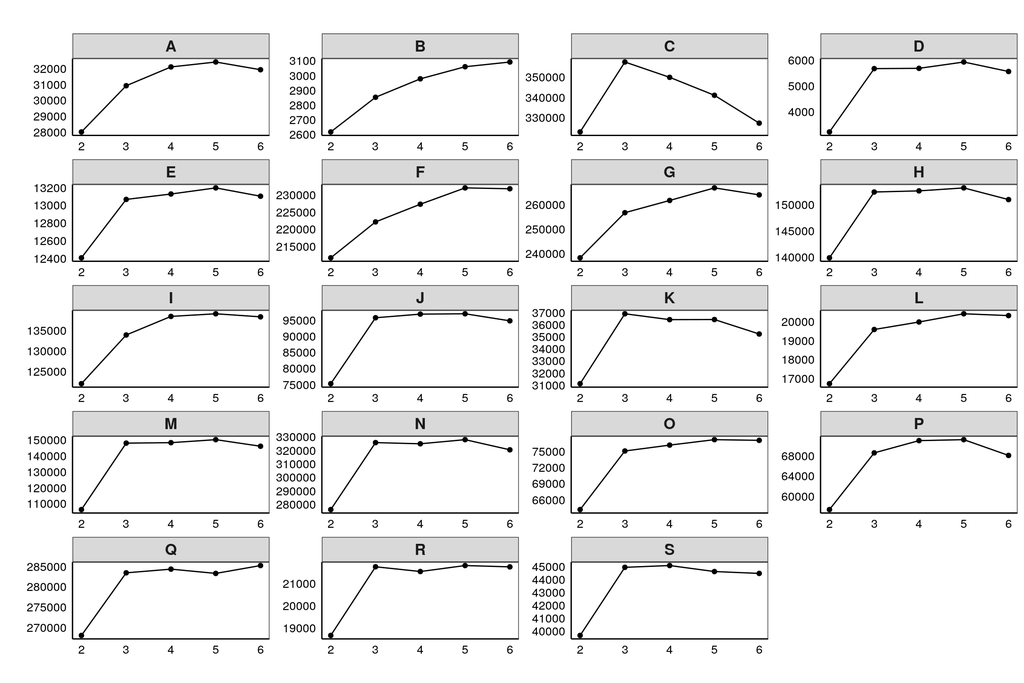

```r
# (relations12.jpeg)

df_nace_beta <- lapply(1:length(models_nace),
                function(x) models_nace[[x]]$fixedeffect); df_nace_beta <- do.call(cbind, df_nace_beta)
df_nace_beta <- cbind(rownames(df_nace_beta), df_nace_beta) %>% data.frame()
colnames(df_nace_beta) <- c("NACE", "2", "3", "4", "5", "6")

df_nace_beta %>%
gather(index, value, 2:6) %>%
mutate(NACE = as.character(NACE),
         index = as.numeric(index),
         value = as.numeric(value),
         value = round(value)) %>%
ggplot() +
geom_line(aes(x = index, y = value)) +
geom_point(aes(x = index, y = value)) +
theme_bw() +
labs(title = "",
     x = "",
     y = "") +
facet_wrap(~NACE, ncol = 4, scales = "free") +
theme(title = element_text(face = "bold", size = 15),
      axis.text.x = element_text(colour = "black", size = 10),
      axis.text.y = element_text(colour = "black", size = 10),
      axis.title.y = element_text(vjust = 2),
      legend.text=element_text(size = 16),
      axis.ticks = element_blank(),
      panel.grid = element_blank(),
      strip.text = element_text(face = "bold", size = 13),
      axis.line = element_line(colour = "black"))
```

# Table 13

Panel data regression between OJA and JVS - ISCO major groups in Hungary

```r
isco <- MERGED_c

isco  %>%
  filter(countries %in% c("Hungary")) -> isco

isco2 <- isco %>%
  select(-countries) %>%
  group_by(isco08, time) %>%
  summarise_all(funs(sum(., na.rm = T))) %>%
  ungroup()

isco_s <- isco %>%
  select(-c(time, countries)) %>%
  group_by(isco08) %>%
  summarise_all(funs(mean(., na.rm = T),
                      sum(., na.rm = T)))


isco_s$rel <- (isco_s$OJA_mean - isco_s$JVS_mean) / isco_s$JVS_mean


isco <- pdata.frame(isco2, index=c("isco08","time"), stringsAsFactors = TRUE)

panel1 <- plm(JVS ~ OJA, data=isco, model="within", effect = "twoways")
summary(panel1)
```

```
## Twoways effects Within Model
##
## Call:
## plm(formula = JVS ~ OJA, data = isco, effect = "twoways", model = "within")
##
## Balanced Panel: n = 9, T = 6, N = 54
##
## Residuals:
##     Min.  1st Qu.   Median  3rd Qu.     Max.
## -1246.42  -414.72   -11.26   340.35  1233.74
##
## Coefficients:
##      Estimate Std. Error t-value Pr(>|t|)
## OJA -0.082924   0.055048 -1.5064     0.14
##
## Total Sum of Squares:    18009000
## Residual Sum of Squares: 17019000
## R-Squared:      0.054985
## Adj. R-Squared: -0.28425
## F-statistic: 2.26919 on 1 and 39 DF, p-value: 0.14003
```

```r
pdwtest(panel1)
```

```
##
##  Durbin-Watson test for serial correlation in panel models
##
## data:  JVS ~ OJA
## DW = 1.5797, p-value = 0.0569
## alternative hypothesis: serial correlation in idiosyncratic errors
```

```r
fixed <- fixef(panel1, effect = "time")
fixef(panel1, effect = "individual")
```

```
##        1        2        3        4        5        6        7        8
##  1599.26 16481.41 13544.43  5172.15  7750.63   583.77  9504.48 12392.94
##        9
## 18221.60
```

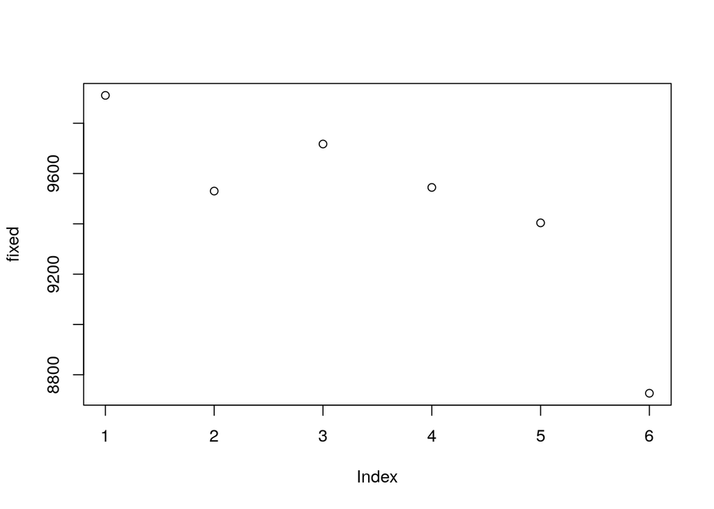

```r
plot(fixed)
```

```r
panel2 <- plm(JVS ~ OJA, data=isco, model="random", effect = "twoways")
summary(panel2)
```

```
## Twoways effects Random Effect Model
##    (Swamy-Arora's transformation)
##
## Call:
## plm(formula = JVS ~ OJA, data = isco, effect = "twoways", model = "random")
##
## Balanced Panel: n = 9, T = 6, N = 54
##
## Effects:
##                      var    std.dev share
## idiosyncratic   436382.6      660.6 0.019
## individual    22336299.6     4726.1 0.974
## time            155812.0      394.7 0.007
## theta: 0.943 (id) 0.5128 (time) 0.5125 (total)
##
## Residuals:
##     Min.  1st Qu.   Median  3rd Qu.     Max.
## -1441.03  -458.79  -115.34   414.36  1756.84
##
## Coefficients:
##                Estimate  Std. Error z-value      Pr(>|z|)
## (Intercept) 9426.013653 1680.584258  5.6088 0.00000002038 ***
## OJA           -0.074853    0.045539 -1.6437        0.1002
## ---
## Signif. codes:  0 '***' 0.001 '**' 0.01 '*' 0.05 '.' 0.1 ' ' 1
##
## Total Sum of Squares:    26151000
## Residual Sum of Squares: 24859000
## R-Squared:      0.049391
## Adj. R-Squared: 0.03111
## Chisq: 2.70178 on 1 DF, p-value: 0.10024
```

```r
pdwtest(panel2)
```

```
##
##  Durbin-Watson test for serial correlation in panel models
##
## data:  JVS ~ OJA
## DW = 1.4215, p-value = 0.01413
## alternative hypothesis: serial correlation in idiosyncratic errors
```

```r
phtest(panel1,panel2)
```

```
##
##  Hausman Test
##
## data:  JVS ~ OJA
## chisq = 0.068101, df = 1, p-value = 0.7941
## alternative hypothesis: one model is inconsistent
```

```r
ranef(panel2)
```

```
##           1           2           3           4           5           6
## -7835.07583  6916.12362  4048.54638 -4270.61199 -1726.01369 -8814.42450
##           7           8           9
##    41.31941  2934.27802  8705.85858
```

```r
panel3 <- plm(JVS ~ OJA, data=isco, model="fd", effect = "individual")
summary(panel3)
```

```
## Oneway (individual) effect First-Difference Model
##
## Call:
## plm(formula = JVS ~ OJA, data = isco, effect = "individual",
##     model = "fd")
##
## Balanced Panel: n = 9, T = 6, N = 54
## Observations used in estimation: 45
##
## Residuals:
##     Min.  1st Qu.   Median  3rd Qu.     Max.
## -1499.81  -467.45   138.26   365.23  1652.50
##
## Coefficients:
##                Estimate  Std. Error t-value Pr(>|t|)
## (Intercept) -260.789651   96.295428 -2.7082 0.009669 **
## OJA           -0.042042    0.024150 -1.7409 0.088854 .
## ---
## Signif. codes:  0 '***' 0.001 '**' 0.01 '*' 0.05 '.' 0.1 ' ' 1
##
## Total Sum of Squares:    18794000
## Residual Sum of Squares: 17556000
## R-Squared:      0.065841
## Adj. R-Squared: 0.044117
## F-statistic: 3.03072 on 1 and 43 DF, p-value: 0.088854
```

```r
pdwtest(panel3)
```

```
##
##  Durbin-Watson test for serial correlation in panel models
##
## data:  JVS ~ OJA
## DW = 2.3599, p-value = 0.8996
## alternative hypothesis: serial correlation in idiosyncratic errors
```